# Netflix Text Analysis

Eralda Gjika

03 December 2022

# Netflix datset text analysis

## Introduction

In this example we are going to do some text and sentimental analysis with the Netflix dataset. The dataset has a lot of information so you may do many analysis based on your research question and target variable.

**Data source:** https://www.kaggle.com/datasets/shivamb/netflix-shows/download?datasetVersionNumber=5

The main libraries we will use are:

```r
library(dplyr)
library(tidytext)
library(ggplot2)
library(ggthemes)
library(stringr)
library(tidyr)
```

```r
library(readr)
netflix_titles <- read_csv("netflix_titles.csv")
View(netflix_titles)
```

Dealing with **stopwords** helps a lot, especially when our text information is not clear and official. Below we may see some of the stop-words used in main libraries, but you may also create your own stop-word vector and remove unnecessary words from your text. For more on this refer to the work done here: https://github.com/EGjika/Text-Analysis-NASA-dataset

```r
data("stop_words")
head(stop_words)
```

| word | lexicon |
| --- | --- |
| a | SMART |
| a's | SMART |
| able | SMART |
| about | SMART |
| above | SMART |
| according | SMART |

```r
# or we may use
stop_words$word[which(stop_words$word %in% sentiments$word)] %>% head(20)
```

```
 [1] "appreciate"    "appropriate"   "available"     "awfully"
 [5] "best"          "better"        "clearly"       "enough"
 [9] "like"          "liked"         "reasonably"    "right"
[13] "sensible"      "sorry"         "thank"         "unfortunately"
[17] "unlikely"      "useful"        "welcome"       "well"
```

## World cloud

For a start we will use wordcloud to have a better view of our text. We may apply it at “description” or even to understand which cast and director has mostly appeared. ### For description

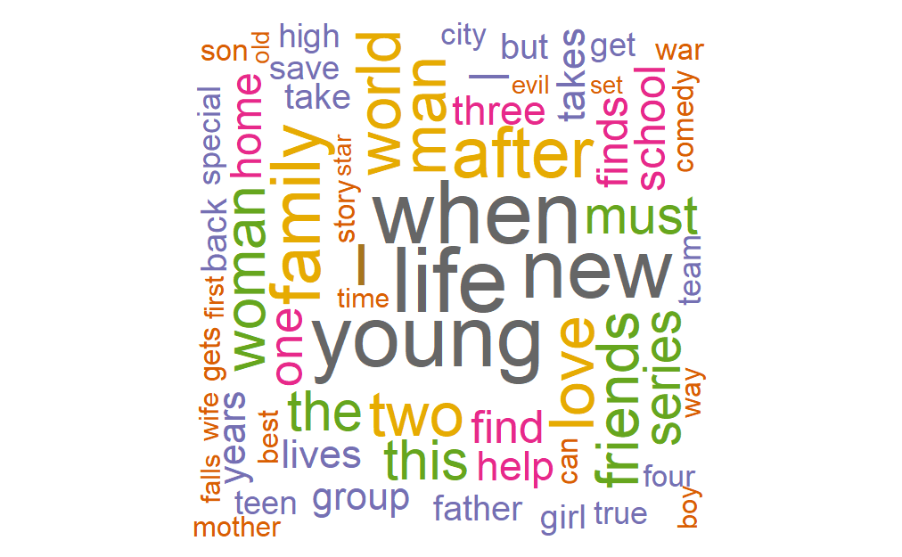

```r
# Libraries used
library(wordcloud)
library(SnowballC)
#generate word cloud
set.seed(1234)
wordcloud(words = netflix_titles$description, max.words=100, random.order=FALSE, rot.per=0.40, colors=brewer.pal(8, "Dark2"))
```